# **Happiness and Television Consumption**

*What is the Relationship Between Individual Happiness and TV Consumption in Germany?*

Author

Affiliations

John Karuitha

Karatina University, School of Business

Graduate School of Business Administration, University of the Witwatersrand

Published

September 8, 2023

Modified

September 8, 2023

Abstract

# **Introduction**

In this analysis, we use data from [the Socio-Economic Panel (SOEP)](https://www.diw.de/sixcms/detail.php?id=875914) to examine the relationship between happiness and the hours of television that respondents watch [^1]. The motivation for the analysis is that maximizing happiness is the key goal of human existence (Cummins, 2012; Singh et al., 2023).

Humans derive happiness from a diverse range activities and life situations. Among the variables associated with happiness include mental, emotional and physical health (Zhang & Chen, 2019), work-life balance, nurturing social relationships for self and others and the harmony with one’s culture, traditions, community, religion, and environment (Singh et al., 2023). The extent to which each of these variables affects happiness varies with individuals (Ali et al., 2020).

```r
## Install required packages
if (!require(pacman)) {
  install.packages("pacman")
}

p_load(
  tidyverse, performance,
  janitor, GGally, psych,
  skimr, gt, kableExtra, styler,
  haven, doParallel, naniar,
  ggthemes, Amelia, plotly,
  nnet, patchwork
)

## Create a parallel computing cluster
cl <- makePSOCKcluster(3)
registerDoParallel(cl)

## Set display options
options(scipen = 999)
options(digits = 3)

## Set a theme for plots
theme_set(ggthemes::theme_clean() +
  theme(axis.text = element_text()))
```

At the macro-level, the drivers of happiness as captured in the [World Happiness Report 2023](https://worldhappiness.report/) include social support, income (per capita income), health (access to quality health care), independence (personal freedoms), generosity, and lack of corruption (Clark et al., 2017; Helliwell et al., 2023). The report ranks Scandinavian countries as the happiest with poor, conflict and corruption prone countries like Afghanistan and Somalia at the bottom [^2].

We define the terms happiness and TV consumption as follows.

- Happiness: I follow the [Oxford dictionary definition of happiness](https://www.oxfordlearnersdictionaries.com/definition/english/happiness). The state of being satisfied that something is good or right. Happiness is hence synonymous with satisfaction.
- TV Consumption: How often a respondent watches television in a week. This metric is categorical varying from watching TV `Daily` to `never` watching TV.

# **Main**

In this section, I load and clean the data and perform data exploration and analysis.

**Tip**

Please visit my rpubs site to see more data projects. Alternatively, copy and paste the link <www.rpubs.com/Karuitha> into your browser. You can also view my linkedin site for my skills and education.

My [Tableau public profile](https://public.tableau.com/app/profile/john.karuitha) contains my data visualizations.

My Shiny web apps are available on this [site](https://karuitha.shinyapps.io/). You can copy-paste this web address instead https://karuitha.shinyapps.io

**Tip**

Skills & Technologies Applied: R, GGPLOT2, Quarto, Data Science.

## **Data**

As noted earlier, the data comes from [SOEP](https://www.diw.de/sixcms/detail.php?id=875914). It is from this data that I pick the variables of interest. Again, the analysis explores the relationship between happiness and television consumption. Consequently, happiness and television consumption are the primary variables. However, I also include some control variables. I define these variables next.

## **Variables**

I select the variables defined in Table 1 below based on the review of literature. Researchers have linked mental, emotional and physical health (Zhang & Chen, 2019), work-life balance, nurturing social relationships for self and others and the harmony with one’s culture, traditions, community, religion, and environment (Singh et al., 2023) to happiness.

```r
tribble(
  ~Variable, ~Description,
  "happy", "Frequency of being happy in the last 4 weeks from 1: very rare to 5: very often",
  "tv", "Hours per week on tv from 1: Daily to 5: Never",
  "mcs", "Summary Scale Mental: Mental Health Indicator", "pcs", "Summary Scale Physical: Physical Health Indicator", "sf_nbs", "Social functioning: Indicator of the state of social life", "sex_v1", "Gender of Individual from 1: Male to 2: Female", "income", "Gross salary as employee Amount previous year"
) %>%
  kbl(caption = "Variables Description") %>%
  kable_classic(full_width = FALSE) %>%
  kableExtra::add_footnote(label = "Source: https://paneldata.org/soep-core/",
               notation = "alphabet")
```

Variables Description

| Variable | Description |
| --- | --- |
| happy | Frequency of being happy in the last 4 weeks from 1: very rare to 5: very often |
| tv | Hours per week on tv from 1: Daily to 5: Never |
| mcs | Summary Scale Mental: Mental Health Indicator |
| pcs | Summary Scale Physical: Physical Health Indicator |
| sf_nbs | Social functioning: Indicator of the state of social life |
| sex_v1 | Gender of Individual from 1: Male to 2: Female |
| income | Gross salary as employee Amount previous year |

<sup>a</sup> Source: https://paneldata.org/soep-core/

## **Data Management**

I read into R the following data sets that contain the variables of interest.

- jugendl.
- Health.
- pl.

```r
jugendl <- read_dta("jugendl.dta")
health <- read_dta("health.dta")
pl <- read_dta("pl.dta")
```

Next, I clean up the data by coding missing values and extracting relevant values. We start with jugendal data.

```r
dt1 <- jugendl %>%
  select(pid, jl0383, sex_v1, jl0088) %>%
  ## Extract codes from happiness and sex
  mutate(jl0383 = str_extract(jl0383, "^-?\\d{1}$")) %>%
  mutate(sex_v1 = str_extract(sex_v1, "^-?\\d{1}$")) %>%
  ## Rename column jl0383 to happy
  rename(happy = jl0383, tv1 = jl0088) %>%
  ## Convert to numeric
  mutate(
    pid = as.numeric(pid),
    happy = as.numeric(happy),
    sex_v1 = as.numeric(sex_v1)
  ) %>%
  ## Code missing values
  mutate(sex_v1 = case_when(
    sex_v1 %in% c(1, 2) ~ sex_v1,
    .default = NA
  )) %>%
  mutate(happy = case_when(
    happy >= 1 ~ happy,
    .default = NA
  )) %>%
  ## Fill up sex as it barely changes
  group_by(pid) %>%
  fill(sex_v1, .direction = "updown") %>%
  fill(sex_v1, .direction = "downup") %>%
  ungroup() %>%
  ## Filter for non-missing data
  filter(happy >= 1) %>%
  ## Convert variables to factors
  mutate(sex_v1 = factor(sex_v1,
    levels = c(1, 2),
    labels = c("Male", "Female")
  )) %>%
  mutate(happy = factor(happy,
    levels = 1:5,
    labels = c(
      "Very Rare", "Rare",
      "Sometime", "Often",
      "Very Often"
    )
  )) %>%
  group_by(pid) %>%
  fill(happy, .direction = "updown")

head(dt1) %>%
  kbl(caption = "Jugendl Dataset Extract") %>%
  kable_classic(full_width = FALSE) %>%
  add_footnote(label = "Source: https://paneldata.org/soep-core/",
               notation = "alphabet")
```

Jugendl Dataset Extract

| pid | happy | sex_v1 | tv1 |
| --- | --- | --- | --- |
| 13904 | Often | NA | -8 |
| 13903 | Very Often | NA | -8 |
| 893403 | Often | Female | -8 |
| 950105 | Often | NA | -8 |
| 950104 | Very Often | NA | -8 |
| 19205 | Very Often | NA | -8 |

<sup>a</sup> Source: https://paneldata.org/soep-core/

Next, I extract some variables from the health data.

```r
dt2 <- health %>%
  select(pid, mcs, pcs, sf_nbs, gh_nbs)

head(dt2) %>%
  kbl(caption = "Health Dataset Extract") %>%
  kable_classic(full_width = FALSE) %>%
  add_footnote(label = "Source: https://paneldata.org/soep-core/",
               notation = "alphabet")
```

Health Dataset Extract

| pid | mcs | pcs | sf_nbs | gh_nbs |
| --- | --- | --- | --- | --- |
| 901 | -8.0 | -8.0 | -8.0 | -8.0 |
| 901 | -8.0 | -8.0 | -8.0 | -8.0 |
| 901 | -8.0 | -8.0 | -8.0 | -8.0 |
| 901 | -8.0 | -8.0 | -8.0 | -8.0 |
| 901 | -8.0 | -8.0 | -8.0 | -8.0 |
| 901 | 68.2 | 29.7 | 57.1 | 45.6 |

<sup>a</sup> Source: https://paneldata.org/soep-core/

Next, I get the data from the pl set of data.

```r
## TV usage per week ----
dt3 <- pl %>%
  select(pid, pli0083, plb0471_h) %>%
  rename(tv = pli0083, income = plb0471_h) %>%
  ## Extract the code
  mutate(tv = str_extract(tv, "^-?\\d{1}$")) %>%
  ## Extract the salary
  mutate(income = str_extract(income, "^-?\\d{1,5}$")) %>%
  ## Convert tv to numeric
  mutate(tv = parse_number(tv)) %>%
  mutate(
    pid = as.numeric(pid),
    income = as.numeric(income)
  ) %>%
  mutate(tv = case_when(
    tv < 1 ~ NA,
    .default = tv
  )) %>%
  mutate(income = case_when(
    income < 1 ~ NA,
    .default = income
  )) %>%
  filter(tv >= 1, !is.na(tv)) %>%
  ## Convert to factor
  mutate(tv = factor(tv,
    levels = 1:5,
    labels = c(
      "Daily",
      "Weekly",
      "Monthly",
      "Rarely",
      "Never"
    )
  ))

head(dt1) %>%
  kbl(caption = "Pl Dataset Extract") %>%
  kable_classic(full_width = FALSE) %>%
  add_footnote(label = "Source: https://paneldata.org/soep-core/",
               notation = "alphabet")
```

| pid | happy | sex_v1 | tv1 |
| --- | --- | --- | --- |
| 13904 | Often | NA | -8 |
| 13903 | Very Often | NA | -8 |
| 893403 | Often | Female | -8 |
| 950105 | Often | NA | -8 |
| 950104 | Very Often | NA | -8 |
| 19205 | Very Often | NA | -8 |

<sup>a</sup> Source: https://paneldata.org/soep-core/

```r
final_data <- dt2 %>%
  left_join(dt3, by = join_by(pid)) %>%
  left_join(dt1, by = join_by(pid)) %>%
  drop_na(tv, happy)

# head(final_data)
```

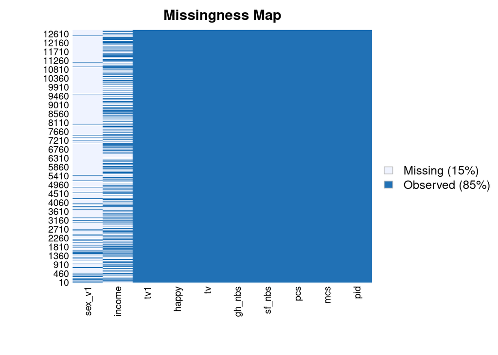

```r
final_data %>%
  Amelia::missmap()
```

## **Sample**

I pick a sample from the observations with complete cases for both TV consumption and happiness. These two are the main variables and hence it is sensible to pick a sample that has these observations in full.

## **Data Visualizations and Data Analysis**

### Summary Statistics

In this section, I summarize the data. I start by doing summary statistics for the entire data set.

#### Numeric Summary

```r
final_data %>%
  select(
    where(is.numeric), -pid,
    -starts_with("syear")
  ) %>%
  skimr::skim_without_charts() %>%
  select(-n_missing, -skim_type) %>%
  rename(
    Mean = numeric.mean,
    SD = numeric.sd,
    Min = numeric.p0,
    Q1 = numeric.p25,
    Median = numeric.p50,
    Q3 = numeric.p75,
    Max = numeric.p100,
    Variable = skim_variable
  ) %>%
  kbl(caption = "Summary Statistics") %>%
  kable_classic(full_width = FALSE) %>%
  add_footnote(label = "Source: https://paneldata.org/soep-core/",
               notation = "alphabet")
```

Summary Statistics

| Variable | complete_rate | Mean | SD | Min | Q1 | Median | Q3 | Max |
| --- | --- | --- | --- | --- | --- | --- | --- | --- |
| mcs | 1.000 | 17.5 | 27.6 | -8 | -8 | -1 | 48.6 | 68.5 |
| pcs | 1.000 | 20.2 | 30.3 | -8 | -8 | -1 | 55.4 | 73.8 |
| sf_nbs | 1.000 | 18.3 | 28.4 | -8 | -8 | -1 | 57.1 | 57.1 |
| gh_nbs | 1.000 | 19.8 | 30.2 | -8 | -8 | -1 | 56.0 | 66.4 |
| income | 0.452 | 1344.8 | 1034.2 | 30 | 580 | 950 | 2000.0 | 6000.0 |
| tv1 | 1.000 | -8.0 | 0.0 | -8 | -8 | -8 | -8.0 | -8.0 |

<sup>a</sup> Source: https://paneldata.org/soep-core/

#### Non-Numeric Summary

```r
final_data %>%
  select(where(is.factor)) %>%
  skimr::skim_without_charts() %>%
  select(-n_missing, -skim_type) %>%
  kbl(caption = "Summary Statistics") %>%
  kable_classic(full_width = FALSE) %>%
  add_footnote(label = "Source: https://paneldata.org/soep-core/",
               notation = "alphabet")
```

Summary Statistics

| skim_variable | complete_rate | factor.ordered | factor.n_unique | factor.top_counts |
| --- | --- | --- | --- | --- |
| tv | 1.000 | FALSE | 5 | Dai: 8657, Wee: 3129, Mon: 518, Rar: 424 |
| happy | 1.000 | FALSE | 5 | Oft: 6857, Ver: 3319, Som: 2060, Rar: 422 |
| sex_v1 | 0.089 | FALSE | 2 | Fem: 641, Mal: 506 |

<sup>a</sup> Source: https://paneldata.org/soep-core/

#### Summary Chart

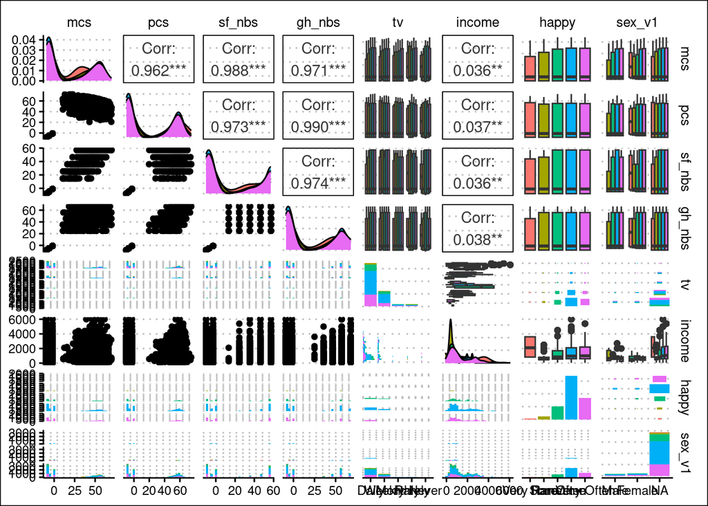

```r
final_data %>%
  select(
    -pid, -tv1,
    -starts_with("syear")
  ) %>%
  GGally::ggpairs(mapping = aes(fill = happy))
```

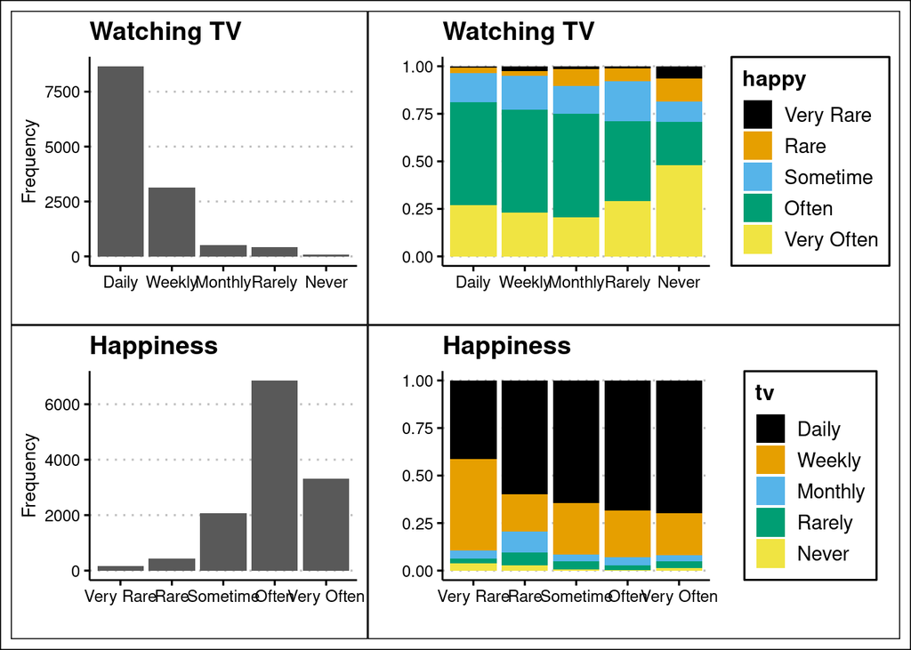

```r
(final_data %>%
  ggplot(mapping = aes(x = tv)) +
  geom_bar(show.legend = FALSE) +
  labs(
    x = "", y = "Frequency",
    title = "Watching TV"
  ) +
  final_data %>%
  ggplot(mapping = aes(x = tv, fill = happy)) +
  geom_bar(position = "fill") +
  labs(
    x = "", y = "",
    title = "Watching TV"
  ) +
  scale_fill_colorblind()) /

  (final_data %>%
    ggplot(mapping = aes(x = happy)) +
    geom_bar(show.legend = FALSE) +
    labs(
      x = "", y = "Frequency",
      title = "Happiness"
    ) +
    final_data %>%
    ggplot(mapping = aes(x = happy, fill = tv)) +
    geom_bar(position = "fill") +
    labs(
      x = "", y = "",
      title = "Happiness"
    ) +
    scale_fill_colorblind())
```

### Happiness vs TV Consumption

#### Chart

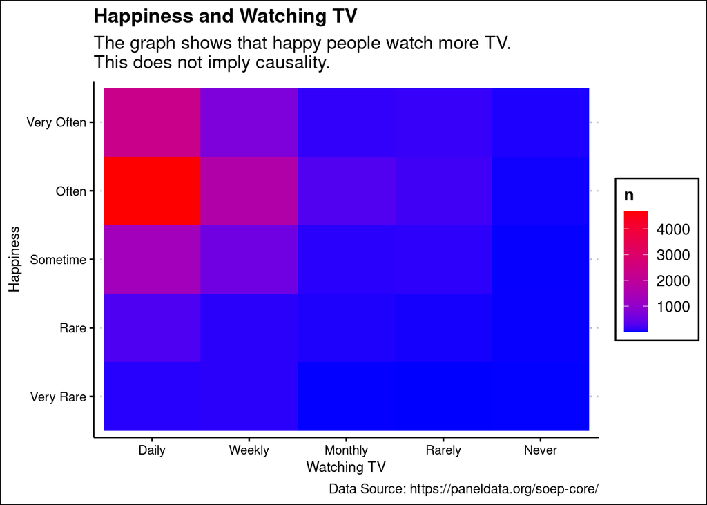

```r
final_data %>%
  count(happy, tv) %>%
  ggplot(mapping = aes(
    y = happy, x = tv,
    fill = n
  )) +
  geom_tile() +
  scale_fill_gradient(
    low = "blue",
    high = "red"
  ) +
  labs(
    y = "Happiness",
    x = "Watching TV",
    title = "Happiness and Watching TV",
    subtitle = "The graph shows that happy people watch more TV.\nThis does not imply causality.",
    caption = "Data Source: https://paneldata.org/soep-core/"
  )
```

#### Table

```r
final_data %>%
  count(happy, tv) %>%
  kbl(caption = "Happiness and TV Consumption") %>%
  kable_classic(full_width = FALSE) %>%
  footnote(general = "Source: Author's Construction Using Data from https://paneldata.org/soep-core/")
```

Happiness and TV Consumption

| happy | tv | n |
| --- | --- | --- |
| Very Rare | Daily | 67 |
| Very Rare | Weekly | 78 |
| Very Rare | Monthly | 7 |
| Very Rare | Rarely | 4 |
| Very Rare | Never | 6 |
| Rare | Daily | 252 |
| Rare | Weekly | 83 |
| Rare | Monthly | 47 |
| Rare | Rarely | 29 |
| Rare | Never | 11 |
| Sometime | Daily | 1329 |
| Sometime | Weekly | 557 |
| Sometime | Monthly | 75 |
| Sometime | Rarely | 89 |
| Sometime | Never | 10 |
| Often | Daily | 4688 |
| Often | Weekly | 1687 |
| Often | Monthly | 282 |
| Often | Rarely | 179 |
| Often | Never | 21 |
| Very Often | Daily | 2321 |
| Very Often | Weekly | 724 |
| Very Often | Monthly | 107 |
| Very Often | Rarely | 123 |
| Very Often | Never | 44 |

Note:  
Source: Author's Construction Using Data from https://paneldata.org/soep-core/

# **Conclusion**

```r
# styler::style_file("Final_juan_david.Rmd")
Sys.info()
```

```
                                                           sysname
                                                           "Linux"
                                                           release
                                          "6.4.6-76060406-generic"
                                                           version
"#202307241739~1692717645~22.04~5597803 SMP PREEMPT_DYNAMIC Tue A"
                                                          nodename
                                                          "pop-os"
                                                           machine
                                                          "x86_64"
                                                             login
                                                        "karuitha"
                                                              user
                                                        "karuitha"
                                                    effective_user
                                                        "karuitha"
```

## References

Ali, S., Murshed, S. M., & Papyrakis, E. (2020). Happiness and the resource curse. *Journal of Happiness Studies*, *21*, 437–464.

Clark, A. E., Flèche, S., Layard, R., Powdthavee, N., & Ward, G. (2017). *The key determinants of happiness and misery*.

Cummins, R. A. (2012). The determinants of happiness. *International Journal of Happiness and Development*, *1*(1), 86–101. https://doi.org/10.1504/IJHD.2012.050833

Helliwell, J. F., Layard, R., Sachs, J. D., De Neve, J.-E., Aknin, L. B., & Wang, S. (2023). *World happiness report*. United Nations.

Singh, S., Kshtriya, S., & Valk, R. (2023). Health, hope, and harmony: A systematic review of the determinants of happiness across cultures and countries. *International Journal of Environmental Research and Public Health*, *20*(4), 3306.

Zhang, Z., & Chen, W. (2019). A systematic review of the relationship between physical activity and happiness. *Journal of Happiness Studies*, *20*(4), 1305–1322.

## Footnotes

[^1]: The description of the variables is available on this [site](http://companion.soep.de/Topics%20of%20SOEPcore/Family%20and%20Social%20Networks.html) or link http://companion.soep.de/Topics%20of%20SOEPcore/Family%20and%20Social%20Networks.html
[^2]: You can access the country-level happiness ranking on this [site](https://www.theglobaleconomy.com/rankings/happiness/) or link https://www.theglobaleconomy.com/rankings/happiness/